# Estudio de los modelos de amortización de préstamos

David Ruiz

10/05/2023

# Introducción

Comparamos los distinto modelos de amortización de préstamos.

```r
# Cargar paquetes necesarios
library(tidyverse)
# Cargar datos
aleman <- read_csv("data/aleman.csv")
americano <- read_csv("data/americano.csv")
frances <- read_csv("data/frances.csv")
# Explorar datos
head(aleman)
```

```
## # A tibble: 6 × 5
##     mes  cuota intereses capital   saldo
##   <dbl>  <dbl>     <dbl>   <dbl>   <dbl>
## 1     0     0         0       0  100000
## 2     1 13333.     5000    8333.  91667.
## 3     2 12917.     4583.   8333.  83333.
## 4     3 12500      4167.   8333.  75000
## 5     4 12083.     3750    8333.  66667.
## 6     5 11667.     3333.   8333.  58333.
```

```r
head(americano)
```

```
## # A tibble: 6 × 5
##     mes cuota intereses capital  saldo
##   <dbl> <dbl>     <dbl>   <dbl>  <dbl>
## 1     0     0         0       0 100000
## 2     1  5000      5000       0 100000
## 3     2  5000      5000       0 100000
## 4     3  5000      5000       0 100000
## 5     4  5000      5000       0 100000
## 6     5  5000      5000       0 100000
```

```r
head(frances)
```

```
## # A tibble: 6 × 5
##     mes  cuota intereses capital   saldo
##   <dbl>  <dbl>     <dbl>   <dbl>   <dbl>
## 1     0     0         0       0  100000
## 2     1 11283.     5000    6283.  93717.
## 3     2 11283.     4686.   6597.  87121.
## 4     3 11283.     4356.   6926.  80194.
## 5     4 11283.     4010.   7273.  72921.
## 6     5 11283.     3646.   7636.  65285
```

Al examinar los datos, podemos ver que los tres modelos tienen la misma estructura de columnas: mes, cuota, intereses, capital y saldo. El modelo alemán y el modelo francés tienen una cantidad fija de cuotas mensuales, mientras que el modelo americano tiene un pago único al final del período de préstamo.

Ahora, podemos empezar a comparar los modelos. Podemos empezar por visualizar la evolución del saldo en cada modelo de amortización. Podemos hacerlo con un gráfico de línea utilizando ggplot2.

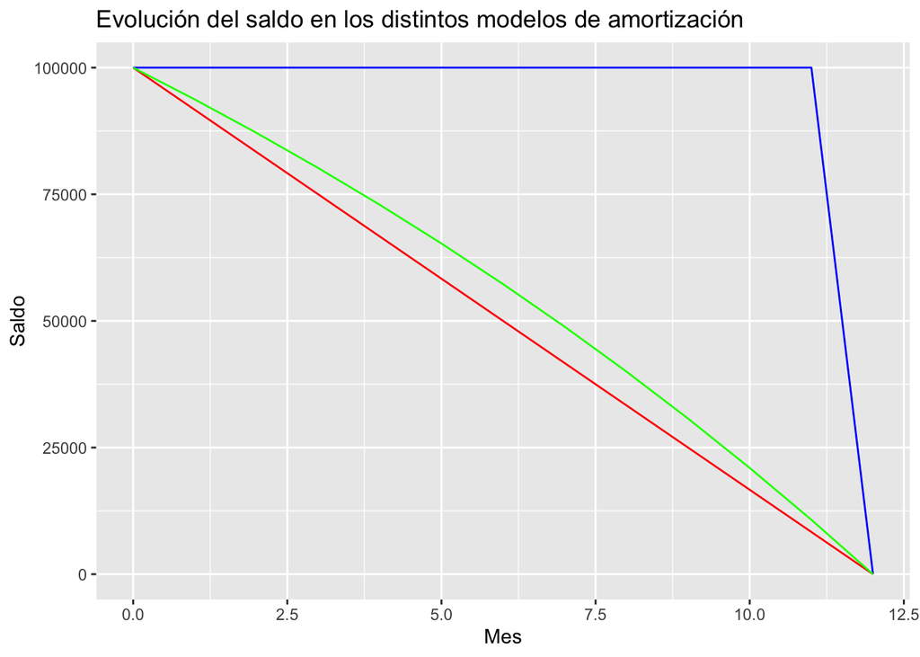

```r
# Graficar saldos
ggplot() +
  geom_line(data = aleman, aes(x = mes, y = saldo), color = "red") +
  geom_line(data = americano, aes(x = mes, y = saldo), color = "blue") +
  geom_line(data = frances, aes(x = mes, y = saldo), color = "green") +
  scale_x_continuous(name = "Mes") +
  scale_y_continuous(name = "Saldo") +
  ggtitle("Evolución del saldo en los distintos modelos de amortización")
```

En este gráfico podemos ver que el modelo americano tiene un saldo constante hasta el último mes, cuando se realiza el pago final. Por otro lado, los modelos alemán y francés tienen una disminución constante del saldo hasta que se llega al pago final.

Otro aspecto interesante a comparar es la cantidad total de intereses pagados en cada modelo. Podemos calcular esta cantidad para cada modelo utilizando la función sum() de R.

```r
# Calcular intereses totales pagados
int_aleman <- sum(aleman$intereses)
int_americano <- sum(americano$intereses)
int_frances <- sum(frances$intereses)

# Mostrar resultados
print(paste("Intereses totales pagados en el modelo alemán:", int_aleman))
```

```
## [1] "Intereses totales pagados en el modelo alemán: 32500"
```

```r
print(paste("Intereses totales pagados en el modelo americano:", int_americano))
```

```
## [1] "Intereses totales pagados en el modelo americano: 60000"
```

```r
print(paste("Intereses totales pagados en el modelo francés:", int_frances))
```

```
## [1] "Intereses totales pagados en el modelo francés: 35390.48"
```

Además, podemos comparar el pago mensual promedio en cada modelo. Podemos hacer esto calculando la media de la columna de cuotas para cada modelo.

```r
# Calcular pago mensual promedio
pago_aleman <- mean(aleman$cuota)
pago_americano <- mean(americano$cuota)
pago_frances <- mean(frances$cuota)

# Mostrar resultados
print(paste("Pago mensual promedio en el modelo alemán:", pago_aleman))
```

```
## [1] "Pago mensual promedio en el modelo alemán: 10192.3076923077"
```

```r
print(paste("Pago mensual promedio en el modelo americano:", pago_americano))
```

```
## [1] "Pago mensual promedio en el modelo americano: 12307.6923076923"
```

```r
print(paste("Pago mensual promedio en el modelo francés:", pago_frances))
```

```
## [1] "Pago mensual promedio en el modelo francés: 10414.6523076923"
```